# Impact of Health Factors on Life Expectancy in Rust Belt States

# 1 Preliminaries

## 1.1 Setup and R Packages

```r
library(janitor)
library(magrittr)
library(broom)
library(tidyverse)
```

## 1.2 Data Ingest

```r
chr_2020_raw <- read_csv("analytic_data2020_raw.csv", guess_max = 3200)
```

# 2 Data Development

## 2.1 Selecting My Data

```r
chr_2020 <- chr_2020_raw %>%
    filter(county_ranked == 1) %>%
    filter(state %in% c("OH", "IN", "MI", "PA")) %>%
    select(fipscode, state, county,
           v147_rawvalue, v003_rawvalue, v069_rawvalue,
           v063_rawvalue, v133_rawvalue) %>%
    rename(life_expectancy = v147_rawvalue,
           uninsured_adults = v003_rawvalue,
           some_college = v069_rawvalue,
           median_household_income = v063_rawvalue,
           food_environment_index = v133_rawvalue)
```

### 2.1.1 Proposal Requirements 1 and 2

```r
chr_2020_counties <- chr_2020 %>%
  group_by(state) %>%
  summarize(number_of_counties = n())
chr_2020_counties
```

```
# A tibble: 4 x 2
  state number_of_counties
  <chr>              <int>
1 IN                    92
2 MI                    83
3 OH                    88
4 PA                    67
```

We chose four states to study: Indiana (92 counties), Michigan (83 counties), Ohio (88 counties), and Pennsylvania (67 counties). Together, these four states comprise a total of 330 counties. We chose to focus on states considered to be part of the “rust belt” region.

## 2.2 Repairing the `fipscode` and factoring the `state`

```r
chr_2020 <- chr_2020 %>%
    mutate(fipscode = str_pad(fipscode, 5, pad = "0"),
           state = factor(state))
```

## 2.3 Mutating Variables to Create Percentages

```r
chr_2020 <- chr_2020 %>%
    mutate(uninsured_percent = uninsured_adults * 100, college_percent = some_college * 100)
```

## 2.4 Creating Binary Categorical Variable

### 2.4.1 Splitting into two categories based on the median

```r
chr_2020 <- chr_2020 %>%
    mutate(food_binary = case_when(is.na(food_environment_index) ~ "other",
                   food_environment_index < median(food_environment_index, na.rm = TRUE) ~ "other",
                   TRUE ~ "high"),
           food_binary = factor(food_binary))
mosaic::favstats(food_environment_index ~ food_binary, data = chr_2020) %>%
    kable(digits = 3)
```

| food_binary | min | Q1 | median | Q3 | max | mean | sd | n | missing |
| --- | --- | --- | --- | --- | --- | --- | --- | --- | --- |
| high | 8.0 | 8.1 | 8.3 | 8.5 | 9.0 | 8.340 | 0.268 | 169 | 0 |
| other | 5.6 | 7.1 | 7.4 | 7.7 | 7.9 | 7.372 | 0.424 | 158 | 3 |

## 2.5 Creating Multi-Category Variable

### 2.5.1 Creating a 4-Category variable with Specified Cutpoints

```r
chr_2020 <- chr_2020 %>%
    mutate(income_cat = case_when(
        median_household_income < 45000 ~ "1_lower",
        median_household_income < 55000 ~ "2_lower_middle",
        median_household_income < 65000 ~ "3_upper_middle",
        TRUE ~ "4_upper"),
        income_cat = factor(income_cat))

mosaic::favstats(median_household_income ~ income_cat, data = chr_2020) %>%
    kable(digits = 3)
```

| income_cat | min | Q1 | median | Q3 | max | mean | sd | n | missing |
| --- | --- | --- | --- | --- | --- | --- | --- | --- | --- |
| 1_lower | 36044 | 40878.50 | 42792.0 | 44410.00 | 44968 | 42365.31 | 2163.317 | 39 | 0 |
| 2_lower_middle | 45130 | 47865.00 | 50002.0 | 52165.00 | 54876 | 49997.78 | 2700.673 | 161 | 0 |
| 3_upper_middle | 55202 | 57117.25 | 59196.5 | 62019.25 | 64992 | 59520.69 | 2790.029 | 90 | 0 |
| 4_upper | 65209 | 67050.75 | 70150.0 | 81637.50 | 103536 | 74880.90 | 10720.501 | 40 | 0 |

## 2.6 Structure of My Tibble

```r
str(chr_2020)
```

```
tibble [330 x 12] (S3: tbl_df/tbl/data.frame)
 $ fipscode               : chr [1:330] "18001" "18003" "18005" "18007" ...
 $ state                  : Factor w/ 4 levels "IN","MI","OH",..: 1 1 1 1 1 1 1 1 1 1 ...
 $ county                 : chr [1:330] "Adams County" "Allen County" "Bartholomew County" "Benton County" ...
 $ life_expectancy        : num [1:330] 79 77.1 78.2 79.3 75.1 ...
 $ uninsured_adults       : num [1:330] 0.1333 0.11 0.1102 0.1224 0.0983 ...
 $ some_college           : num [1:330] 0.523 0.668 0.667 0.592 0.55 ...
 $ median_household_income: num [1:330] 56693 54473 63067 51649 45161 ...
 $ food_environment_index : num [1:330] 8.1 7.3 7.8 8.4 8.3 8.9 8.7 8.7 8.6 7.9 ...
 $ uninsured_percent      : num [1:330] 13.33 11 11.02 12.24 9.83 ...
 $ college_percent        : num [1:330] 52.3 66.8 66.7 59.2 55 ...
 $ food_binary            : Factor w/ 2 levels "high","other": 1 2 2 1 1 1 1 1 1 2 ...
 $ income_cat             : Factor w/ 4 levels "1_lower","2_lower_middle",..: 3 2 3 2 2 4 3 3 2 3 ...
```

# 3 Codebook

| Variable | Description |
| --- | --- |
| fipscode | FIPS code |
| state | State: our four states are IN, MI, OH, and PA |
| county | County Name |
| life_expectancy | (v147) Life expectancy |
| uninsured_adults | (v003) Proportion of uninsured adults |
| some_college | (v069) Proportion of Adults 25-44 with post-secondary education |
| median_household_income | (v063) Median Household Income |
| food_environment_index | (v133) Food Environment Index |
| food_binary | 2 levels: other = food_environment_index below 8 or missing value, high = greater than or equal to 8 |
| income_cat | 4 levels: lower = median_household_income below 45k, lower_middle = between 45-55k, upper_middle = between 55-65k, upper above 65k |
| uninsured_percent | Percentage of uninsured adults |
| college_percent | Percentage of Adults 25-44 with post-secondary education |

## 3.1 Proposal Requirements 1 and 2

We chose four states to study: Indiana (92 counties), Michigan (83 counties), Ohio (88 counties), and Pennsylvania (67 counties). Together, these four states comprise a total of 330 counties. We chose to focus on states considered to be part of the “rust belt.”

The variables chosen are as follows:

- The outcome variable is `life_expectancy`, which was originally variable `v147_rawvalue`, and listed in the Length of Life subcategory of Health Outcomes at the County Health Rankings. It describes the average number of years a person can expect to live, based on age-specific death rates. This measure is age-adjusted and sourced from the 2016-2018 National Center for Health Statistic Mortality Files. Life expectancy was chosen as our outcome variable due to its ease for interpretation, in comparison to other measures of mortality.
- The first quantitative predictor is `uninsured_adults`, which was originally variable `v003_rawvalue`, and listed in the Access to Care subcategory of Clinical Care at the County Health Rankings. It describes the percentage of people under 54 without health insurance coverage. This measure is created from statistical modeling, using data from the US Census Bureau’s 2017 Small Area Health Insurance Estimates program. This variable is of interest because health insurance coverage is a large barrier to providing health care access in many communities.
- The second quantitative predictor is `some_college`, which was originally variable `v069_rawvalue`, and listed in the Education subcategory of Social & Economic Factors at the County Health Rankings. It describes the percentage of adults ages 25-44 with some post-secondary education. This includes, but is not limited to, vocational schools, junior colleges, and four-year colleges. This measure counts those who pursued post-secondary education, but did not receive a degree in addition to those who attained degrees. Data is sourced from the 2014-2018 American Community Survey’s 5-year estimates. We chose this variable because higher education is typically thought to lead to better paying jobs, which provide better health insurance and quality health care.
- The multi-categorical predictor is `median_household_income`, which was originally variable `v063_rawvalue`, and listed in the Income subcategory of Social & Economic Factors at the County Health Rankings. It describes the income where half of the households in a county earn more and the other half earn less. This measure is created from statistical modeling, using data from the 2018 Small Area Income and Poverty Estimates program. We chose this variable because median household income is a strong indicator of income inequality between counties, which is directly linked to differences in health care outcomes.
- The binary predictor is `food_environment_index`, which was originally variable `v133_rawvalue`, and listed in the Diet and Exercise subcategory under Health Behaviors at the County Health Rankings. This measure is a scaled index that equally weighs two food environment indicators, limited access to healthy foods and food insecurity, on a scale from 0 (worst) to 10 (best). Limited access to healthy foods examines the percentage of low-income households less than 10 miles from a grocery store. Food insecurity estimates the percentage of low-income households which did not have a reliable source of food. Data is sourced from the 2015 & 2017 USDA Food Environment Atlas. This variable was chosen because food environment is important to maintaining a healthy lifestyle, and there is strong evidence food deserts plays a role in health outcomes.

## 3.2 Summarizing the tibble

```r
chr_2020
```

```
# A tibble: 330 x 12
   fipscode state county life_expectancy uninsured_adults some_college
   <chr>    <fct> <chr>            <dbl>            <dbl>        <dbl>
 1 18001    IN    Adams~            79.0           0.133         0.523
 2 18003    IN    Allen~            77.1           0.110         0.668
 3 18005    IN    Barth~            78.2           0.110         0.667
 4 18007    IN    Bento~            79.3           0.122         0.592
 5 18009    IN    Black~            75.1           0.0983        0.550
 6 18011    IN    Boone~            78.6           0.0743        0.800
 7 18013    IN    Brown~            78.4           0.113         0.650
 8 18015    IN    Carro~            79.3           0.113         0.542
 9 18017    IN    Cass ~            76.0           0.150         0.496
10 18019    IN    Clark~            74.9           0.0989        0.638
# ... with 320 more rows, and 6 more variables: median_household_income <dbl>,
#   food_environment_index <dbl>, uninsured_percent <dbl>,
#   college_percent <dbl>, food_binary <fct>, income_cat <fct>
```

```r
Hmisc::describe(chr_2020)
```

```
chr_2020

 12  Variables      330  Observations
--------------------------------------------------------------------------------
fipscode
       n  missing distinct
     330        0      330

lowest : 18001 18003 18005 18007 18009, highest: 42125 42127 42129 42131 42133
--------------------------------------------------------------------------------
state
       n  missing distinct
     330        0        4

Value         IN    MI    OH    PA
Frequency     92    83    88    67
Proportion 0.279 0.252 0.267 0.203
--------------------------------------------------------------------------------
county
       n  missing distinct
     330        0      262

lowest : Adams County     Alcona County    Alger County     Allegan County   Allegheny County
highest: Williams County  Wood County      Wyandot County   Wyoming County   York County
--------------------------------------------------------------------------------
life_expectancy
       n  missing distinct     Info     Mean      Gmd      .05      .10
     330        0      330        1    77.42    2.077    74.60    75.32
     .25      .50      .75      .90      .95
   76.23    77.46    78.58    79.74    80.34

lowest : 71.58650 72.48029 72.50651 72.66190 72.76081
highest: 81.92076 82.37232 82.43664 82.83152 82.92225
--------------------------------------------------------------------------------
uninsured_adults
       n  missing distinct     Info     Mean      Gmd      .05      .10
     330        0      330        1  0.08739  0.02235  0.05926  0.06590
     .25      .50      .75      .90      .95
 0.07318  0.08437  0.09679  0.11239  0.12609

```

[output cut: 47 more lines]

```
       n  missing distinct
     330        0        2

Value       high other
Frequency    169   161
Proportion 0.512 0.488
--------------------------------------------------------------------------------
income_cat
       n  missing distinct
     330        0        4

Value             1_lower 2_lower_middle 3_upper_middle        4_upper
Frequency              39            161             90             40
Proportion          0.118          0.488          0.273          0.121
--------------------------------------------------------------------------------
```

## 3.3 Checking the Data

```r
chr_2020 %>%
    summarize(sum(is.na(.)))
```

```
# A tibble: 1 x 1
  `sum(is.na(.))`
            <int>
1               3
```

There are three missing values for the food environment index variable and none for any other variable.

```r
mosaic::favstats(food_environment_index ~ state, data = chr_2020) %>%
    select(state, n, missing) %>%
    mutate(pct_available = 100*(n - missing)/n) %>%
    kable()
```

| state | n | missing | pct_available |
| --- | --- | --- | --- |
| IN | 90 | 2 | 97.77778 |
| MI | 82 | 1 | 98.78049 |
| OH | 88 | 0 | 100.00000 |
| PA | 67 | 0 | 100.00000 |

All variables are available in at least 75% of the counties in each state.

```r
chr_2020 %>%
    summarize(across(life_expectancy:food_environment_index, ~n_distinct(.))) %>%
    kable()
```

| life_expectancy | uninsured_adults | some_college | median_household_income | food_environment_index |
| --- | --- | --- | --- | --- |
| 330 | 330 | 330 | 327 | 30 |

The raw versions of the selected variables all have more than 10 distinct non-missing values.

```r
chr_2020 %>% tabyl(food_binary)
```

```
 food_binary   n   percent
        high 169 0.5121212
       other 161 0.4878788
```

```r
chr_2020 %>% tabyl(income_cat)
```

```
     income_cat   n   percent
        1_lower  39 0.1181818
 2_lower_middle 161 0.4878788
 3_upper_middle  90 0.2727273
        4_upper  40 0.1212121
```

For the categorical variables, each category contains at least 10 counties.

## 3.4 Saving the Tibble

```r
saveRDS(chr_2020, file = "chr_2020_Patrick_Wu_Long_Vu.Rds")
```

## 3.5 Final Proposal Requirement

The most challenging part of assembling the proposal was determining how to deal with the missing values for the Food Environment Index. The missing values prevented us from separating the Food Environment Index values into the desired binary categories. While we determined that the missing values were the issue relatively quickly, we were not sure how to create the categories without creating another data set. We tried to assign the missing values to a third category but this initially did not work. However, eventually the desired result was achieved after excluding the missing values when calculating the median.

# 4 Analysis 2

## 4.1 The Variables

The outcome variable for this analysis is life expectancy. This is the average number of years a person can expect to live based on age-specific death rates in a particular county. The predictor variable for this analysis is median household income. This includes incomes from wages, salaries, self-employment, interest, dividends, rentals, royalties, estates, trusts, Social Security, Railroad Retirement, Supplemental Security Income, public assistance, welfare, and pensions. It does not include capital gains, non-business sale of property, food stamps, subsidies for public housing or medical care, withdrawal of bank deposits, money borrowed, tax refunds, gifts, lump-sum inheritances, or insurance payments. Income is described with 4 categories – annual income less than 45000, from 45000 to 55000, from 55000 to 65000, and 65000 and above. Each of these categories includes its lower bound but not its upper bound.

The outcome variable is named life_expectancy and the predictor variable is named income_cat. They are contained in a tibble named chr_2020, which contains complete data from all the counties in Indiana, Michigan, Ohio, and Pennsylvania.

```r
cuyahoga <- chr_2020 %>%
  filter(county == "Cuyahoga County")
```

Cuyahoga County, Ohio has a life expectancy of 76.85 and a median household income category of 2_lower_middle.

## 4.2 Research Question

The research question for this analysis is as follows:

Are progressively higher-income categories associated with progressively higher life expectancy in the 330 counties of Indiana, Michigan, Ohio, and Pennsylvania?

## 4.3 Visualizing the Data

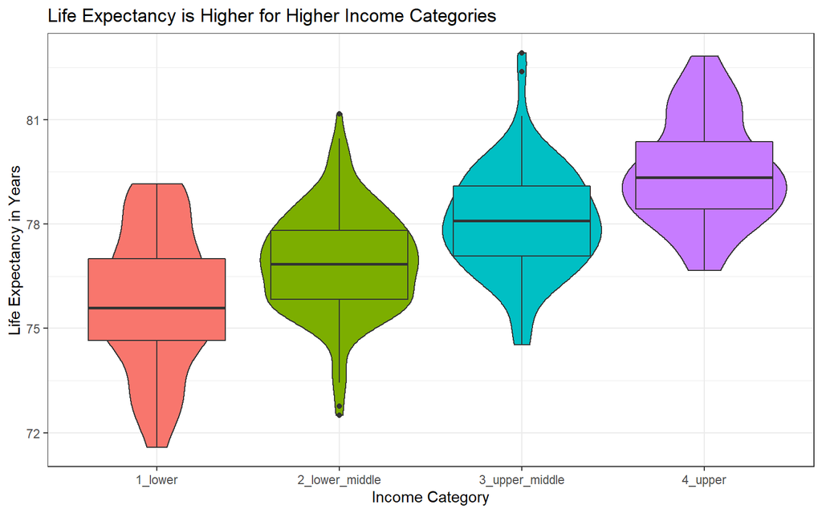

```r
ggplot(data = chr_2020, mapping = aes(x = income_cat, y = life_expectancy, fill = income_cat)) +
  geom_violin(show.legend = FALSE) +
  geom_boxplot(show.legend = FALSE) +
  theme_bw() +
  labs(title="Life Expectancy is Higher for Higher Income Categories", y="Life Expectancy in Years", x="Income Category")
```

## 4.4 The Fitted Model

```r
model2 <- lm(life_expectancy ~ income_cat, data = chr_2020)
tidy(model2, conf.int = T, conf.level = 0.90) %>% kable(dig = 2)
```

| term | estimate | std.error | statistic | p.value | conf.low | conf.high |
| --- | --- | --- | --- | --- | --- | --- |
| (Intercept) | 75.82 | 0.25 | 305.24 | 0 | 75.41 | 76.23 |
| income_cat2_lower_middle | 1.09 | 0.28 | 3.94 | 0 | 0.63 | 1.55 |
| income_cat3_upper_middle | 2.28 | 0.30 | 7.67 | 0 | 1.79 | 2.77 |
| income_cat4_upper | 3.69 | 0.35 | 10.56 | 0 | 3.11 | 4.26 |

```r
glance(model2) %>%
  select(r.squared, statistic, df, df.residual,
         p.value, sigma, nobs) %>%
  kable(dig = c(3, 2, 0, 0, 4, 2, 0))
```

| r.squared | statistic | df | df.residual | p.value | sigma | nobs |
| --- | --- | --- | --- | --- | --- | --- |
| 0.313 | 49.52 | 3 | 326 | 0 | 1.55 | 330 |

The prediction equation is as follows:

Predicted Life Expectancy = 75.82 + 1.09(Category 2) + 2.28(Category 3) + 3.69(Category 4)

The intercept of this equation, 75.82, is the predicted life expectancy (or mean life expectancy) for the counties in the lowest income category. The predicted life expectancy for the next highest income category is 1.09 years greater than this value and is thus 76.91. Similarly, the predicted life expectancy for the second highest income category is 2.28 + 75.82 or 78.1 and the predicted life expectancy for the highest income category is 3.69 + 75.82 or 79.51. These values correspond with the pattern observed in the boxplot, where each progressively higher income category is associated with an increased life expectancy of at least 1 year relative to the previous category.

The model has an R-squared of 0.313. In other words, 31.3% of the variance in life expectancy among counties is predictable using the four income categories. The residual standard error of the model is 1.55 and the model was fit to 330 observations.

## 4.5 Prediction Analysis

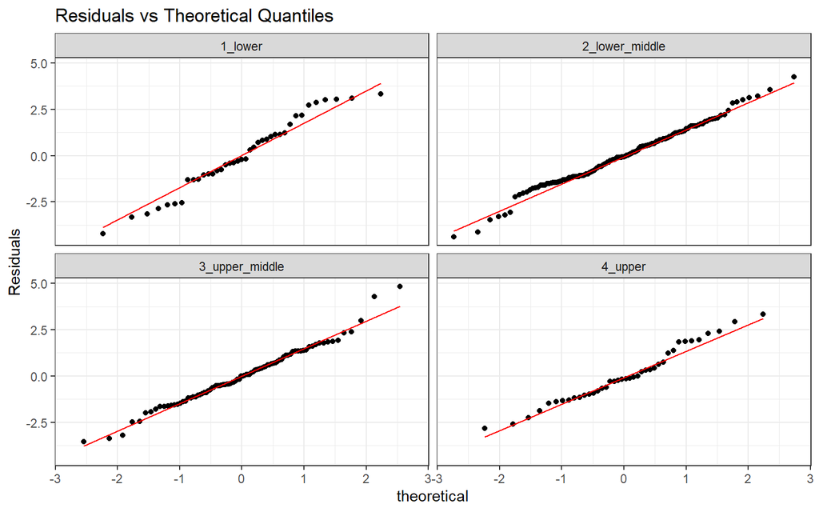

```r
augment2 <- augment(model2, chr_2020)

ggplot(augment2, aes(sample = .resid)) +
  geom_qq() +
  geom_qq_line(col = "red") +
  theme_bw() +
  facet_wrap(~ income_cat) +
  labs(title = "Residuals vs Theoretical Quantiles",
       y = "Residuals")
```

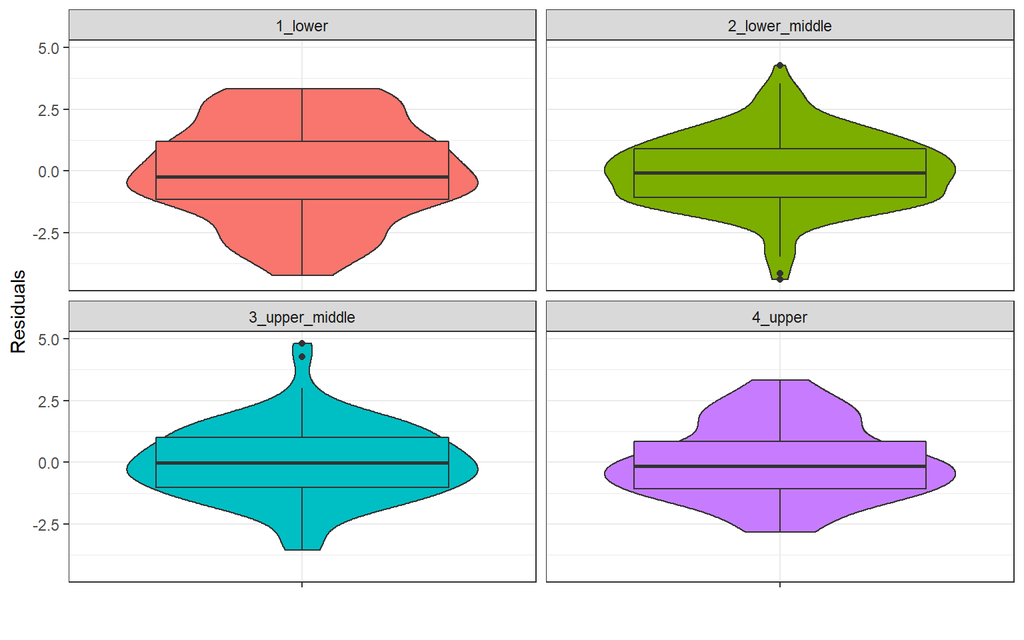

```r
ggplot(augment2, aes(y = .resid, x = "", fill = income_cat)) +
  geom_violin(show.legend = FALSE) +
  geom_boxplot(show.legend = FALSE) +
  theme_bw() +
  facet_wrap(~ income_cat) +
  labs(y = "Residuals", x = "")
```

```r
augment2 <- augment2 %>%
  mutate(residual = abs(.resid)) %>%
  arrange(desc(residual)) %>%
  select(state, county, residual, .resid)

augment2
```

```
# A tibble: 330 x 4
   state county          residual .resid
   <fct> <chr>              <dbl>  <dbl>
 1 PA    Centre County       4.83   4.83
 2 IN    Fayette County      4.40  -4.40
 3 PA    Union County        4.28   4.28
 4 OH    Noble County        4.26   4.26
 5 IN    Scott County        4.23  -4.23
 6 OH    Pike County         4.15  -4.15
 7 OH    Brown County        3.56  -3.56
 8 MI    Benzie County       3.56   3.56
 9 IN    Jennings County     3.46  -3.46
10 IN    Howard County       3.37  -3.37
# ... with 320 more rows
```

The normal Q-Q plots and boxplots show reasonable normality for the residuals in each category, though the highest and lowest income categories seem notably less normal than the other two. The model predicted Cuyahoga County’s life expectancy to be 76.91, while the actual life expectancy was 76.85. The two counties where the model was least successful in predicting life expectancy were Centre County in Pennsylvania and Fayette County in Indiana.

## 4.6 Conclusions and Limitations

The goal of this analysis was to determine whether progressively higher-income categories were associated with progressively higher life expectancy in the 330 counties of Indiana, Michigan, Ohio, and Pennsylvania. The results of the analysis indicate that higher-income categories are indeed associated with correspondingly higher life expectancies. Each income category exhibited a mean and median life expectancy at least 1 year greater than the corresponding values for the income category directly below it. Specifically, the mean life expectancy for counties with a median annual household income of less than $45,000 was 75.82. The mean life expectancy for counties with a median annual household income of $45,000 to $55,000 was 76.91. The mean life expectancy for counties with a median annual household income of $55,000 to $65,000 was 78.1. Finally, the mean life expectancy for counties with a median annual household income of $65,000 or greater was 79.51.

The primary concern for this analysis is a relative lack of normality in the life expectancies and therefore the residuals for the counties in the lowest and highest income categories. This suggests that these categories may be better represented through further subdivision. Alternatively, quantitative values for median household income could be used in the analysis rather than categories. Furthermore, this analysis applies only to the county level and the conclusions drawn cannot be applied to individual households either in the states of interest or elsewhere.